# Anomaly detection and other artificial intelligence tools in industry 4.0

11th July 2022  
https://is.gd/Parnell_MM_talk

## Contents

1. An introduction to artificial intelligence

2. Some examples of artificial intelligence used by the I-Form centre

## What is ML and AI?

- Machine Learning (ML) and Artificial Intelligence (AI) are methods to make a computer take input data and make *predictions*.
- In the recent past, a huge explosion in data has led to the *Big Data* revolution:
  - Volume
  - Variety
  - Veracity
  - Velocity

## Examples of AI: Character and voice recognition

[figure not shown]

## Genomics

[figure not shown]

## Additive Manufacturing

[figure not shown]

## What makes these data all the same?

- They each have a *target* that we’re trying to predict (a digit, the size of a tumour, an aspect of a tool)
- They each have a large number of *features* which we can use to predict the target (pixels, genes, sensor data)
- The data can be written as *rectangular data structures* (like an Excel spreadsheet)
- We make the predictions using a *learner*. There are lots of different types, from linear regression to deep neural networks

## Testing performance

- To determine the performance of our AI models we usually separate the data into a *training set* and a *test set*
- Taken together the data set, the target variable and the features are known as a *task*
- We *train* the learner on the training set and then *predict* on the test set
- Seeing as we know the target values for the test set we can determine how far away they are from the truth

## A workflow in R

```r
library(mlr)
# Make a task
task_1 = makeRegrTask(data = my_data_set, target = 'y')
# Create training and test sets
test_set = sample(n,size = n/4)
train_set = (1:n)[-test_set]
# Set up a leaner
learner_1 = makeLearner('regr.h2o.deeplearning')
# Train it on the training data
train_1 = train(learner = learner_1, task = task_1, subset = train_set)
# Predict on the test set data
pred_1 = predict(object = train_1, task = task_1, subset = test_set)
# Check performance
performance(pred_1)
```

## A reminder of the terminology

- A *task* is the data set, the *features*, and the *target* variable
- A *training* and *test* set are just the rows of the data that we will train and test our model on
- A *learner* is a black box that aims to predict the target from the features
- The *predictions* on the test set can be compared to the true target values to judge the performance of the learner

## Learners 101: Linear regression

- We aim to estimate \(f()\) in: \[y = f(X) + e\]
- The simplest useful model is a *linear regression* model: \[f = a + b_1 x_1 + b_2 x_2 + b_3 x_3 + \ldots \]
- We might minimise the *least squares loss function*: \[\sum (y - f(X))^2\] We find the `best’ values of \(a\), \(b_1\), \(b_2\) etc that *minimise the loss*

## From linear regression to deep learning

Make the \(b\) terms depend on other *hidden* \(b\) terms to produce richer functional behaviour

[figure not shown]

## Types of AI

[figure not shown]

## Running the digits data through R

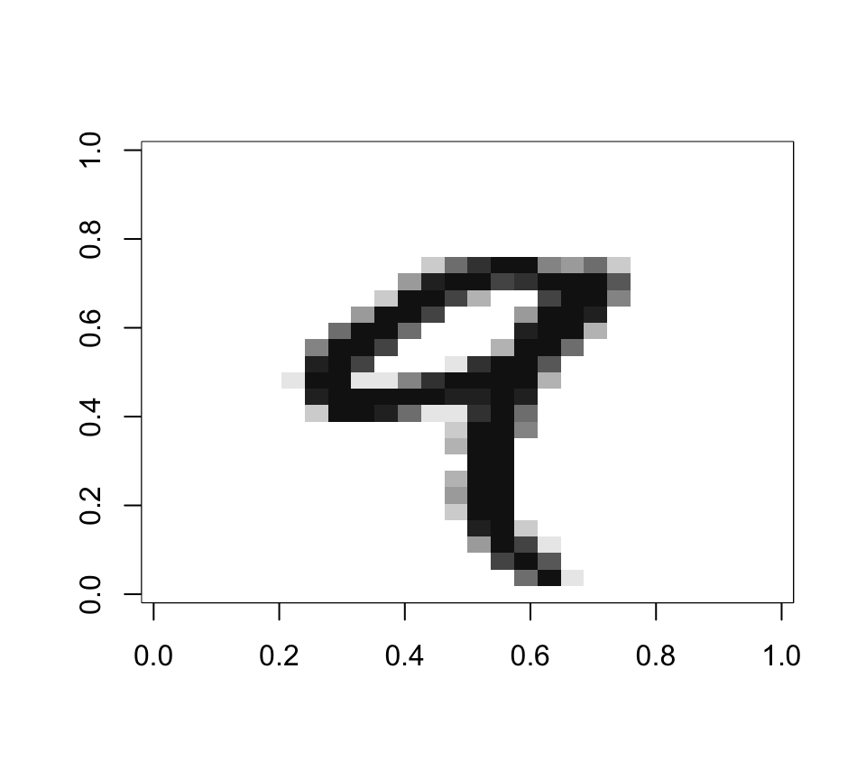

```r
show_digit(train$x[5,])
```

## What does the data look like?

```r
mnist[1:6, c(405:410, 785)] # 0 = white, 255 = black
```

```
##   pix405 pix406 pix407 pix408 pix409 pix410 digit
## 1      0     81    240    253    253    119     5
## 2      0      0      0      0      0      0     0
## 3    144    150    241    243    234    179     4
## 4     80    240    251    193     23      0     1
## 5    197    241    253    252    251     77     9
## 6    179    253    253    255    253    253     2
```

Each image is 28 by 28 pixels

## Fitting a deep learning classifier

```r
# Make a task and set up training/test sets
task_mn = makeClassifTask(data = mnist, target = 'digit')
train_set = 1:60000
test_set = 60001:70000
# Set up a leaner
learner_dl = makeLearner('classif.h2o.deeplearning',
                         predict.type = 'prob')
# Train it on the training data
train_dl = train(learner = learner_dl, task = task_mn, subset = train_set)
pred_dl = predict(object = train_dl, task = task_mn, subset = test_set)
# Check performance
```

```r
print(performance(pred_dl))
```

```
##   mmce
## 0.0284
```

## How well did it do?

```
##    class
##        0    1    2    3    4    5    6    7    8    9
##   0  963    0    1    1    0    2    6    1    2    4
##   1    0 1126    3    1    0    0    1    2    2    0
##   2    1    2 1008    5    1    0    3    7    3    2
##   3    0    0    4  996    0    2    0    6    1    1
##   4    1    1    7    2  954    0    6    2    0    9
##   5    3    0    0   19    1  850    6    3    5    5
##   6    3    2    2    0    3   12  934    0    2    0
##   7    1    3    9    4    1    0    1 1003    2    4
##   8    1    1    5   17    5    7    7   10  918    3
##   9    3    4    2   12    9    2    0   11    2  964
```

## What about other ML models?

- With `mlr` it is easy to train other models in the same way

```r
learner_rf = makeLearner('classif.h2o.randomforest',
                         predict.type = 'prob')
# Train it on the training data
train_rf = train(learner = learner_rf, task = task_mn,
                 subset = train_set)
# Predict on the test set data
pred_rf = predict(object = train_rf, task = task_mn,
                  subset = test_set)
print(performance(pred_rf))
```

[output not shown]

## Assessing performance of ML models

- A good model should have predicted values close to the true values, or predicted classes close to the true classes. Some models will also produce uncertainties (e.g. intervals) or probabilities which can help determine the quality of the fit
- The usual metrics people use are the *root mean squared error* (for regression problems), the *misclassification rate* (for classification problems)
- Other more advanced metrics for classifiers include the *receiver operator characteristic curve* and *precision-recall curve*. These work on the probabilities of each observation being in a particular class

## Neural network extensions

- *Convolutional and recurrent* neural networks designed for image or time series data
- *Transfer learning* where we use a pre-trained neural network that might have seen similar data to that which we are modelling
- *Active learning* which allows for the user to train the model (e.g. provide labels) on data that the model is struggling to predict
- *Probabilistic uncertainty* when we require more than just predictions
- There are many more!

## Part 2: AI and I-Form

## Common problems in AI and manufacturing

- *Extracting data* from the machine
- Fast and accurate analysis of *high-dimensional* data
- *Human labelling* of the data stream
- *Interpreting* the analytics for the user so that they can take action

## A recommender system

[video not shown]

## Recommender system structure

[figure not shown]

## Recommender system interface

[video not shown]

## Anomaly detection 1: Control charts

[figure not shown]

## Anomaly detection 2: Model-based clustering

[figure not shown]

## Anomaly detection 3: STRAY

[figure not shown]

## Anomaly detection 4: Autoencoders

[figure not shown]

## Using STRAY to detect defects

[figure not shown]

## Image detection to classify pores

[figure not shown]

## How to learn more about AI in AM

[figure not shown]

## Summary

- In the near future we will be *regularly streaming* large amounts of data from AM machines and analysing it in real time to identify defects as they occur
- The tools of AI are *important to learn* and will help you ride the wave of Industry 4.0/5.0
- Come and join the *I-Form centre* in Phase 2 if you want to help work on extending these ideas

## Resources and funding

[I-Form](https://www.i-form.ie), [MNIST code](http://yann.lecun.com/exdb/mnist/), [Types of Machine Learning picture](https://rayenmhamdi.github.io/ai/ml/), [Control charts](https://anhoej.github.io/qicharts2/), [Model based clustering](https://mclust-org.github.io), [STRAY](https://github.com/pridiltal/stray), [Autoencoders](https://medium.com/@birla.deepak26/autoencoders-76bb49ae6a8f), [Doyle STRAY paper](https://www.sciencedirect.com/science/article/pii/S235197892100175X), [I-Form Github repo](https://github.com/I-Form)

**All materials and code: [Github repo](https://github.com/andrewcparnell/MM_talk)**

This work was supported by a Science Foundation Ireland Career Development Award grant 17/CDA/4695 and Research Centre Award 16/RC/3872

Thank you!